# Assignment Introduction

## Introduction

Wow.

What an assignment. I must say this ranks as the hardest assignment I have done. Talking with Mohit, I would say this ranks as one of her hardest too. Out of the fire however, we have forged a great deal of new learning. Before this assigment we had no idea what neural networks are, or even how scikitlearn or tensorflow works. Now I can explain it to my 65 year old mother what deep learning is, and she barely knows how to send a text message on a cell phone.

In this assignment, you will see various notebooks. The wider variety are from me, as I am rather messy and am still learning. ALL of my submissions are indeed standing on the shoulders of giants, I surely would not have been able to submit anything without some serious googling and opening of many tabs. References are in the various Bibliography's with one exception where my computer froze and shut me out. A tab lost forever, an I can't for the life of me remember how I got there. Mohit's work is very neat. As a much more experienced computer programmer, Mohit understands much more about how programming and coding works and is thus able to cut through a great deal of the exra unnecessary code that I have included. Her references are inlcuded in her books.

As I have departed from my normal Bottom Line Up Front (BLUF) format for introductions, please feel free to start from here if you wish to skip some reading.

This assignment we have created an EDA for the both of us that is formatted in a regimental manner for all the datasets. This did give us some great insights. These are included in the EDA file. We have created a KNN and gauged it's usefulness. This was completed my Mohit. Her EDA is included. We also did a Keras, and a Pytorch. I (Thomas) did those. Explainations are included in the notebooks, with another two different methods of gauging usefulness or effectiveness. We have also included a K-Mean clustering analysis like we did in the lecture. Mohit completed this. I have attempted a K-Means analysis, which is also included, but as so far as we are about to submit the notebooks, I am unable to get it to work properly, as I don't fully understand scikitlearn, and can't (yet) get the preprocessor to re-scale the two axis for a nice comparison. I attempted a Gaussian NB, I didn't get it to work at the time of submission and is not included, as this was the reference that I could not find.

From this we learnt: We can use the prior preformance to predict the future. This comes with some serious qualifiers thougn...

1. It's not accurate.
2. It lags reality. Whilst the machine is learning the new reality as it passes through the model, there will be some lag with it having to learn. This could be overcome through the use of other classifiers or variables being included in the model. Completely understand this was likely the overall goal of this assignment, and I absolutely take my hat off to whoever achieved that, but I can tell you we did not. The five bonus marks will be left on the pitch for next time.

## The Kaggle Submission

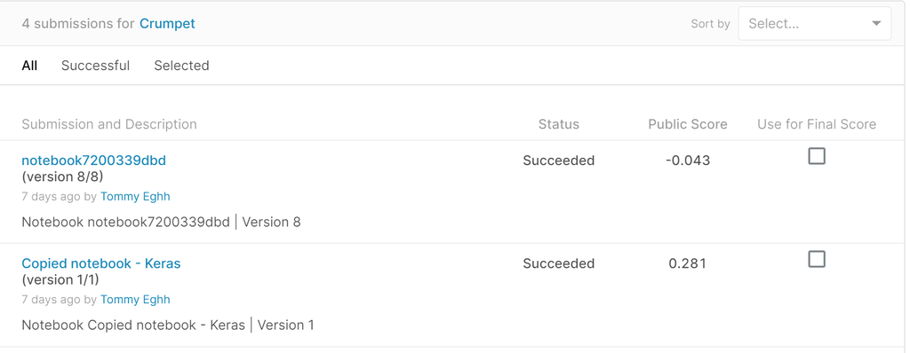

Right... Please let me explain...

So I had no idea how to submit one of these notebooks to kaggle and I found it impossible without seeing a working copy submitted first. So I copied a notebook from a sucessful submitter (not me) submitted it, learnt from the process and then figured out what worked and what didn't.

SO MUCH FUN! So much learning in this assignment. This took me so long to fugure it all out, but we got there in the end. I have not included any increases in marks as it is well beyond my abilities to tune the model by including further variables or machine learning algorithms, thus I sadly note that we are unable to claim the coveted extra 5 marks or indeed get the full marks of the Kaggle submission.

## Conclusion

We can absolutely predict the future prices with machine learning models based on one very arbitrary variable - the closing price of the stock.

Neural Networks are fantastic. Using them and implementing them is very easy using the open source tools availble. Understanding exactly how they work is rather complicated. The more one reads about such things the easier it is to understand, and I have found that understanding other networks or machine learning algorithms is enhanced as we learn more.

Machine learning implementation is not terrifically difficult. Whilst this assignment has stretched my abilities in particular, it has set a new expectation and level that we are able to leverage from for the future.

KNN is not really suitable for this type of data. It is apparently a much better classifier. I think it would be great to implement KNN on a dataset that is intended for it. I intend to enter another competition where I am not duty bound to send orignal work and learn much more by copying more learned people than I. Whilst this is not recommended long term, it is a good way of learning by absorption.

EDA saves a lot of time and effort. Understanding the data beforehand and understnading the quesitons asked of the data is key. This wasn't actually immediately apparent and for this project, could be interpreted in a number of ways. Whilst the output of the data should remain the same which is the top 200 and bottom 200 stocks, leaving creative ways to get there was a good thing. I think in future projects, I will exploit this as my abilities catch up with intention.